# Data-analyse en ecologie

Dromen en hindernissen

Johan van Tent

15 april 2019

## Over mijzelf

- Adviseur waterkwaliteit en ecologie
- Beheerder grote hoeveelheid ecologische data
- Beperkte soortenkennis
- Enthousiast over dingen doen met data
- https://github.com/RedTent **

# De dromen

## Soorten vertellen een verhaal

- Individueel en als gemeenschap
- Over het verleden
- Over de huidige omstandigheden
- Over de bijzonderheid van de situatie
- En vast nog veel meer…

## Wat is dat verhaal?

Ik wil begrijpen wat het verhaal is dat de aanwezige soorten vertellen

En vooral:

### Hoe kom ik daar achter?

## Mogelijkheden

- Er wordt veel biologie geïnventariseerd
- Er is veel soortenkennis
- De techniek wordt steeds geavanceerder

## Begrip van de situatie!

Het is mogelijk om het verhaal van de soorten te kennen!

Dan moeten we de mogelijkheden goed benutten!

In de praktijk blijkt het toch lastig te zijn

### Wat houdt ons tegen?

# Hindernissen

## Geen toegang tot informatiebronnen

- Onwetendheid dat de informatie er is
- Informatie zit in de hoofden van mensen
- Informatie zit “verstopt”
  - in tools
  - achter wachtwoorden

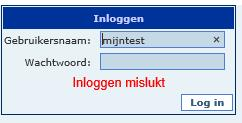

## Lastig in gebruik

- Tools
  - Vaak maar bruikbaar voor 1 doel
  - Format is vaak uniek
- Grote hoeveelheden monsters analyseren kan vaak niet
- Informatie komt in allerlei vormen en maten

Bijvoorbeeld:

## Van Dam Index

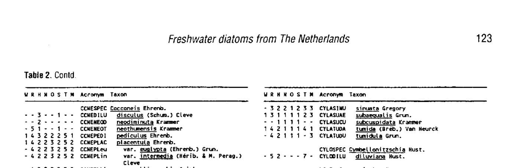

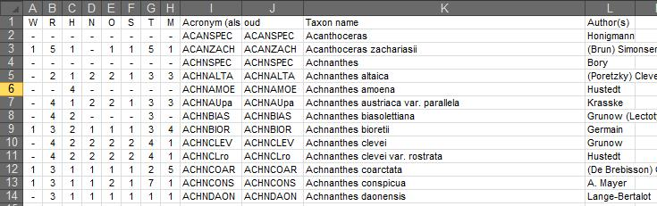

## Of de WEW-macrofaunalijst

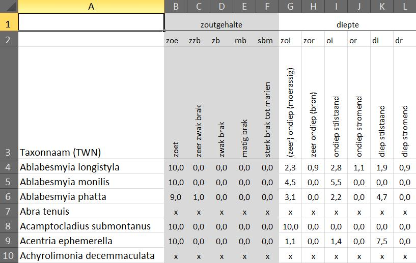

## Of info uit de verwijderingstool

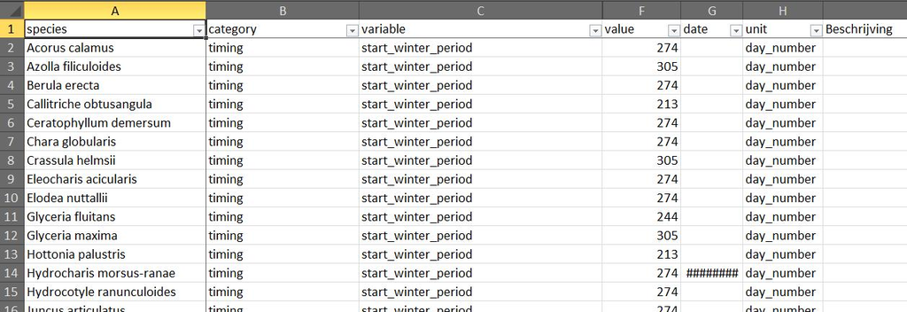

## Wat is de behoefte?

Data-analyse is al mogelijk

Maar is vaak lastig en arbeidsintensief

**Kan het makkelijker?**

# Doelen

## Mijn doelen voor de dag

- Kennis opdoen van analysemogelijkheden
- Elkaar leren kennen - opbouw van een netwerk
- Overzicht krijgen van databronnen met relevante (auto-ecologische) informatie

**Samen data-analyse makkelijker maken!**

## Toekomstdroom?!

- Auto-ecologische informatie is vrij, uniform en centraal beschikbaar
- Tools maken gebruik van deze ‘open data’

## Toetsen

- n = next
- p = previous
- f = fullscreen
- o = overview (of Esc)
- b = black
- f = fullscreen (of F11)